# Project1

Justin

6/24/2020

```r
# load csv
activityData <- read.csv("activity.csv", header=TRUE)

# load necessary libraries for later analysis
library(ggplot2)
```

What is mean total number of steps taken per day? For this part of the assignment, you can ignore the missing values in the dataset.

Calculate the total number of steps taken per day If you do not understand the difference between a histogram and a barplot, research the difference between them. Make a histogram of the total number of steps taken each day Calculate and report the mean and median of the total number of steps taken per day

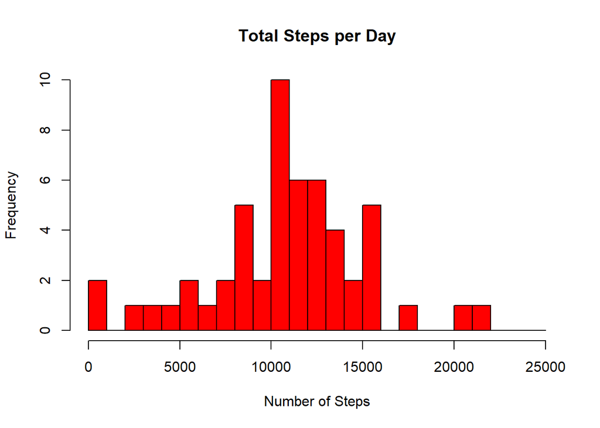

```r
# Begin by calculating total # of steps taken per day and ignore NA
StepsPerDay <- aggregate(steps ~ date, activityData, FUN=sum, na.rm = TRUE)

# histogram of the total number of steps taken per day filled in with red
hist(StepsPerDay$steps,
     breaks = seq(from=0, to=25000, by=1000),
     col = "red",
     main = "Total Steps per Day",
     xlab = "Number of Steps")
```

```r
# Calculate and report the mean and median of total steps taken per day
Steps_mean <- mean(StepsPerDay$steps, na.rm = TRUE)
Steps_median <- median(StepsPerDay$steps, na.rm = TRUE)
```

Answer: mean is 10766.19 and median is 10765.

What is the average daily activity pattern? Make a time series plot (i.e. type = “l”) of the 5-minute interval (x-axis) and the average number of steps taken, averaged across all days (y-axis) Which 5-minute interval, on average across all the days in the dataset, contains the maximum number of steps?

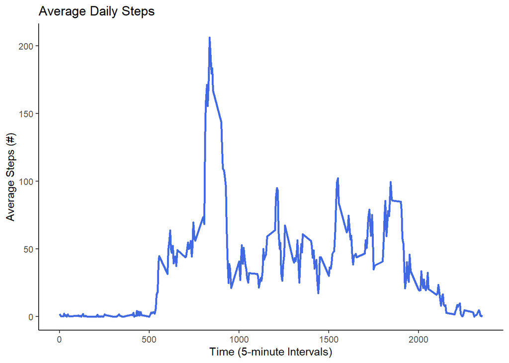

```r
# This figure will be created using ggplot2 and with a classic theme so no gridlines will be behind the data line. The data line will be blue and x and y axes labeled accordingly along with a brief title.
library(ggplot2)
Mean_StepsPer5min <- aggregate(steps ~ interval, activityData, mean)
ggplot(data = Mean_StepsPer5min, aes(x = interval, y = steps)) +
  geom_line(color="royalblue", size=1) +
  ggtitle("Average Daily Steps") +
  xlab("Time (5-minute Intervals)") +
  ylab("Average Steps (#)") +
  theme(plot.title = element_text(hjust = 0.5))+
  theme_classic() +
  scale_colour_hue(name = "Steps")
```

```r
# This script will find the point where the max point is and return its value
GreatestStepsPer5min <- Mean_StepsPer5min[which.max(Mean_StepsPer5min$steps),]
```

Next Question:

Imputing missing values Note that there are a number of days/intervals where there are missing values (coded as NA). The presence of missing days may introduce bias into some calculations or summaries of the data.

Devise a strategy for filling in all of the missing values in the dataset. The strategy does not need to be sophisticated. For example, you could use the mean/median for that day, or the mean for that 5-minute interval, etc.